# Checking IHS Results

```r
library(tidyverse)
library(terra)
library(sf)
library(leaflet)
library(scico)
library(flextable)
```

To test the replication, SoLIM is used with the prepared covariates as follows:

1. Obtain the software from the [SoLIM website](https://solim.geography.wisc.edu/software/index.htm) (or me)
2. Run `SoLIMSolutions.exe`

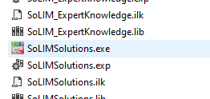

1. Use tool `‘Utilities > Data format conversion > GDAL-supported raster formats -> 3dr’` to convert the covariate TIFs exported earlier to the required ‘.3dr’ file format.

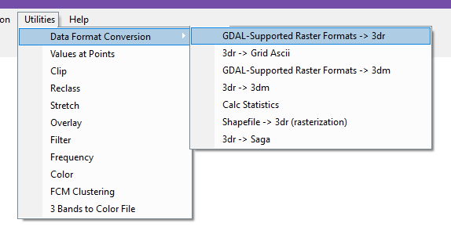

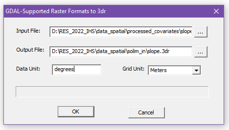

4. Use the tool `Sample Design > Purposive Sampling (Yang etc.)` to carry out the analysis.

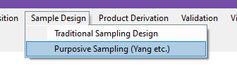

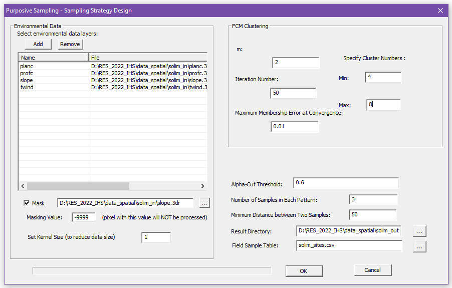

The tool settings should be:

- all 4 covariates loaded
- tick the ‘mask’ checkbox and choose any of the covariates. set the Masking Value field to -9999 (otherwise the no-data value in each layer will be included in the cluster analysis D:)
- leave the default settings for m, iteration number, and membership error
- cluster min 4, max 8
- alpha-cut threshold 0.6
- N samples/pattern 3
- min dist 50m
- set output folder and nominate a file name for the ‘test sites’ csv

Once the program is run, the outputs appear in a set of subfolders at the nominated destination. The key one is `/patterns`, which holds 3dr files that represent the equivalent of the cluster chain surfaces produced above. Only the surfaces for unique chains are output. The outputs are summarised in `/pattern_list.csv`, which looks quite similar to the table of ECC data produced in the previous documents.

Below, R outputs are compared with SoLIM’s.

```r
eccs <- read_csv(file.path('sample_plan', 'ECC_table.csv'))

solim_eccs <-
  read_csv(file.path('data_spatial', 'solim_out', 'pattern_list.csv'))
```

ECC data, unique cluster chains, >20 cells

| ecc_name | rep_grade | rep_area | uid |
| --- | --- | --- | --- |
| 2-2-2-2-8 | 5 | 1,107 | 1 |
| 3-3-6-6-6 | 5 | 275 | 2 |
| 1-1-5-1-1 | 5 | 134 | 3 |
| 1-5-5-1-5 | 5 | 113 | 4 |
| 2-1-1-7-2 | 5 | 80 | 5 |
| 1-1-1-7-1 | 5 | 37 | 6 |
| 2-2-0-7-2 | 4 | 81 | 16 |
| 4-5-3-5-0 | 4 | 30 | 21 |
| 3-3-0-3-3 | 4 | 26 | 22 |

ECC data from SoLIM

| Name | Stability | Area | ID |
| --- | --- | --- | --- |
| 4Class2-5Class3-6Class6-7Class1-8Class5 | 5 | 1,077 | 11 |
| 4Class4-5Class1-6Class4-7Class4-8Class2 | 5 | 281 | 1 |
| 4Class3-5Class4-6Class3-7Class6-8Class8 | 5 | 127 | 2 |
| 4Class3-5Class2-6Class3-7Class6-8Class6 | 5 | 102 | 3 |
| 4Class3-5Class2-6Class5-7Class5-8Class6 | 5 | 71 | 4 |
| 4Class2-5Class2-6Class5-7Class5-8Class1 | 5 | 52 | 7 |
| 4Class2-5Class3-7Class5-8Class1 | 4 | 116 | 12 |
| 4Class2-5Class3-6Class6-8Class1 | 4 | 37 | 10 |
| 4Class4-6Class2-7Class2-8Class7 | 4 | 31 | 13 |
| 4Class1-5Class4-6Class1-7Class3 | 4 | 26 | 8 |
| 4Class4-5Class1-7Class2-8Class7 | 4 | 24 | 15 |

Looking at both documents, the first entries don’t look very similar, but plotting the maps for the first row from each shows the following:

```r
ecc_01 <- terra::rast(file.path('data_spatial', 'ecc_results',
                                'ecc_01.tif'))


solim_ecc_01 <- terra::rast(file.path('data_spatial', 'solim_out',
                                      'patterns', 'pattern11.asc'))
crs(solim_ecc_01) <- crs(ecc_01)

ecc_diff <- solim_ecc_01 - ecc_01
```

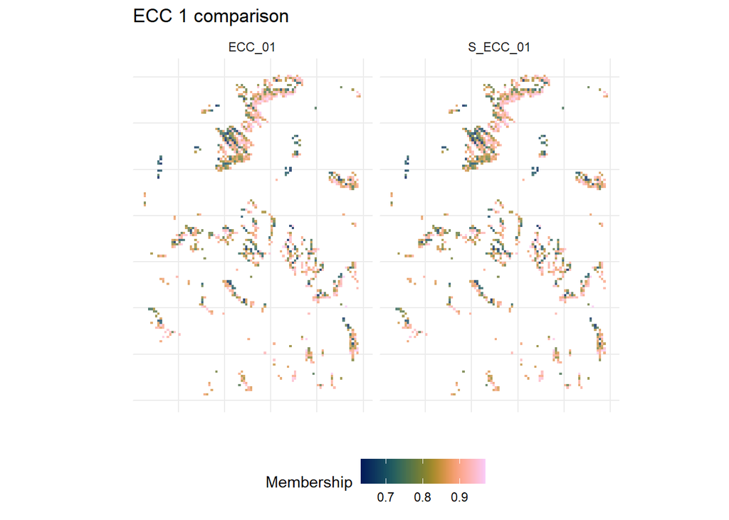

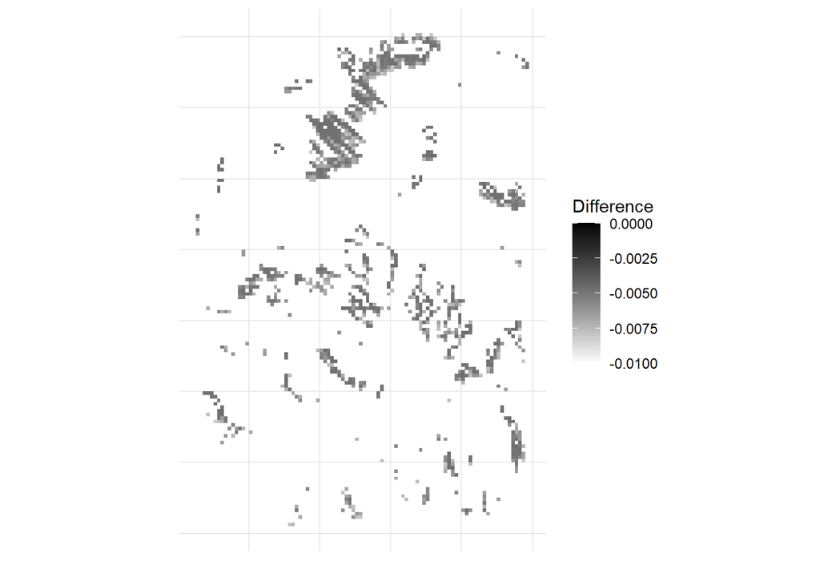

There are some minor differences in membership and total pixel count, but overall we can see that the method has been replicated.